# A toy MCMC example

Author

Michael Chong

Published

February 6, 2026

## The idea

- binary coin flip outcome ($y = 0$ or $y=1$)
- coin might be biased: $y=1$ with probability $\theta$
- coin can only be fair, or biased in one way: either $\theta = 0.9$ or $\theta = 0.5$
- you believe a priori that it is unlikely you have a biased coin: $P(\theta = 0.9) = 0.3$ and $P(\theta = 0.5) = 0.7$

## The posterior

Imagine you observe $y=1$.

We can calculate all the components of the posterior according to Bayes rule:

- likelihood:
  - $p(y=1|\theta = 0.9) = 0.9$
  - $p(y=1|\theta = 0.5) = 0.5$
- priors: see above
- the scaling factor ($p(y) = \sum_\theta p(y|\theta) p(\theta)$)
  - $(0.9 \times 0.3) + (0.5 \times 0.7) = 0.27 + 0.35 = 0.62$

So the posterior $p(\theta|y)$ is:

- $p(\theta =0.5| y) = \frac{0.5\times 0.7}{0.62} \approx 0.564$
- $p(\theta =0.9| y) = \frac{0.9\times 0.3}{0.62} \approx 0.435$

## MCMC quantities

We need a few things for basic MCMC: 1. proposal distribution and 2. the acceptance probabilities.

For the proposal distribution, denote the current iteration as $\theta_k$ and the proposed next iteration as $\theta^*$. Construct the proposal distribution such that we always propose the *other* value of $\theta$. Write $p(\theta^* | \theta_k)$ as:
$$j(\theta^* | \theta_k) =
\begin{cases}
1 & \text{if } \theta^* \not = \theta_k \\
0 & \text{otherwise}.
\end{cases}$$
(Technical note: this proposal distribution is symmmetrical in the sense that $j(y|x) = j(x|y)$, so we’re in the plain Metropolis regime (not Metropolis-Hastings))

Our acceptance probabilities can be calculated:
$$R(0.5 \rightarrow 0.9) = \min \left\{1, \frac{p(y=1|\theta = 0.9)p(\theta=0.9)}{p(y=1|\theta = 0.5)p(\theta=0.5)}\right\} = \min \left\{1, \frac{0.9 \times 0.3}{0.5 \times 0.7 } \right\} = \min\{1, 0.7714...\} = 0.7714...$$
and
$$R(0.9 \rightarrow 0.5) = \min \left\{1, \frac{0.5 \times 0.7 }{0.9 \times 0.3} \right\} = 1$$
So we *always* move from 0.9 to 0.5, but only sometimes move from 0.5 to 0.9.

## Simulation

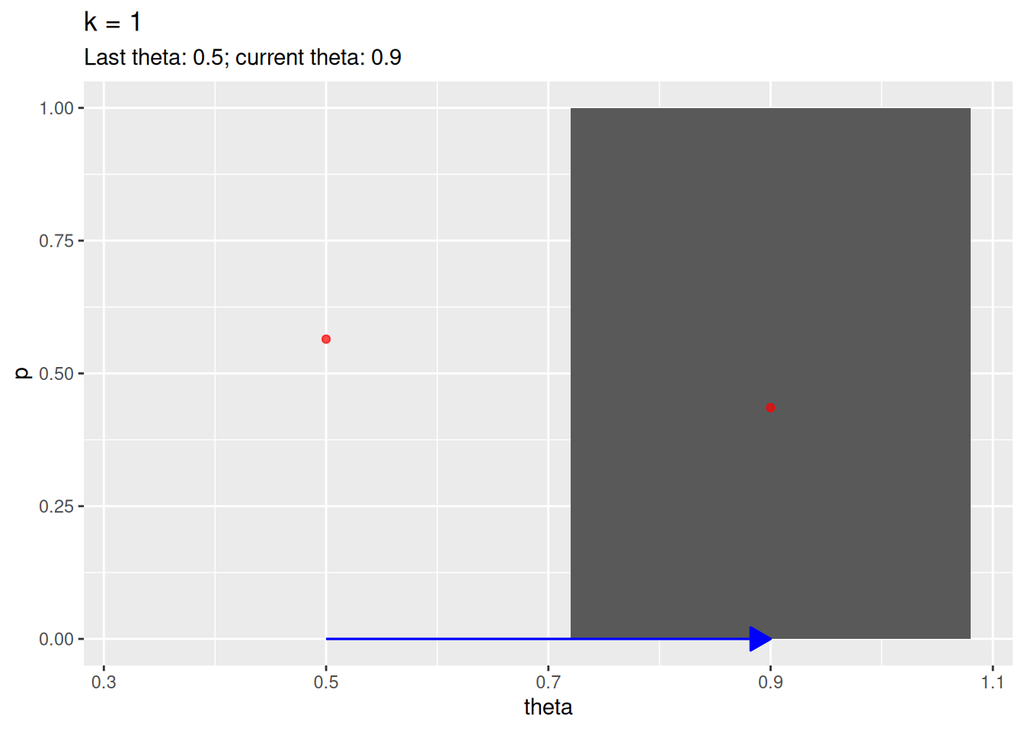

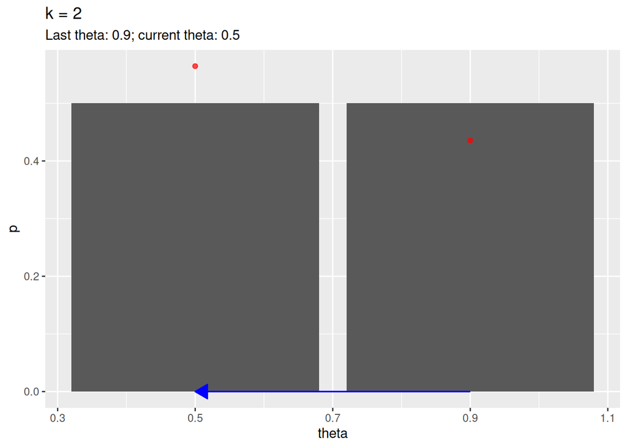

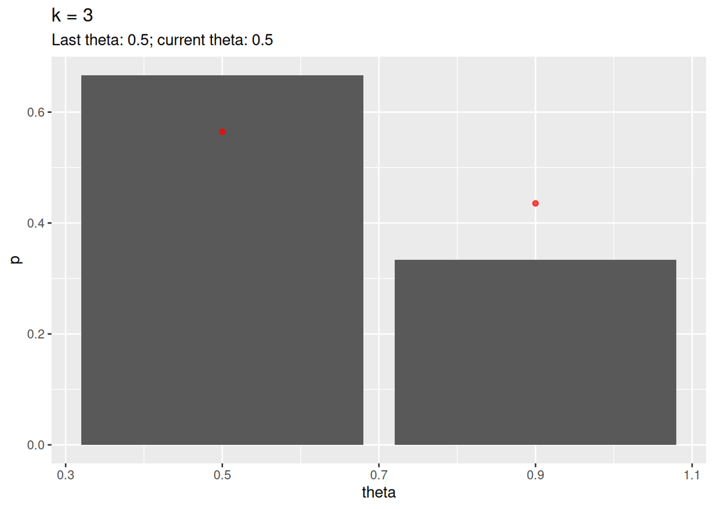

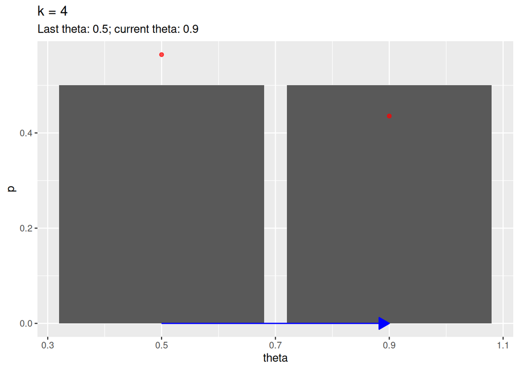

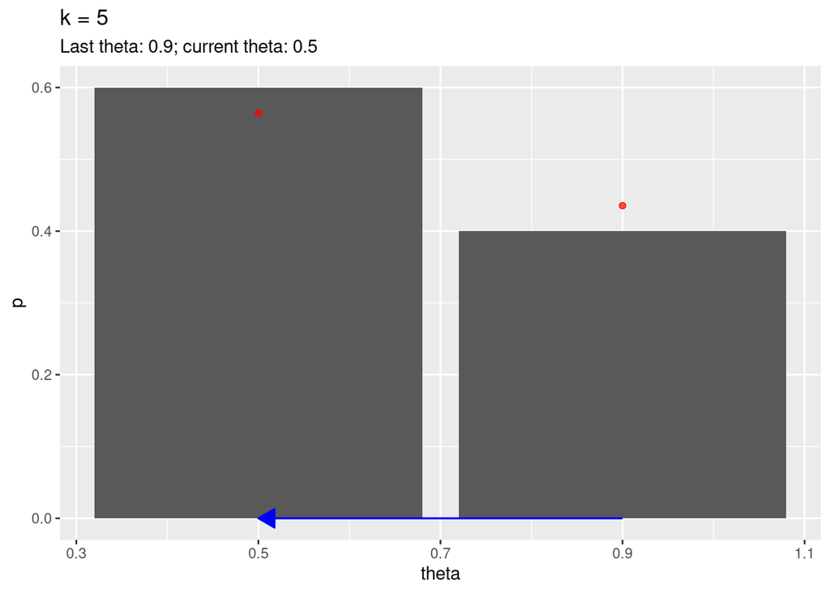

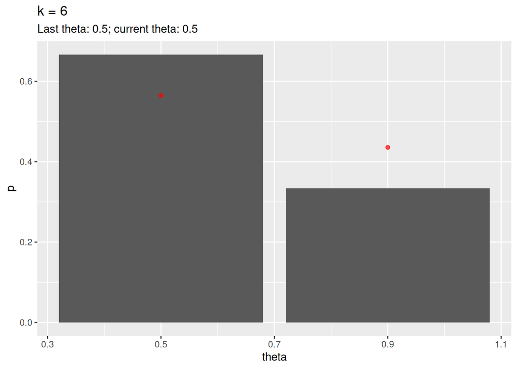

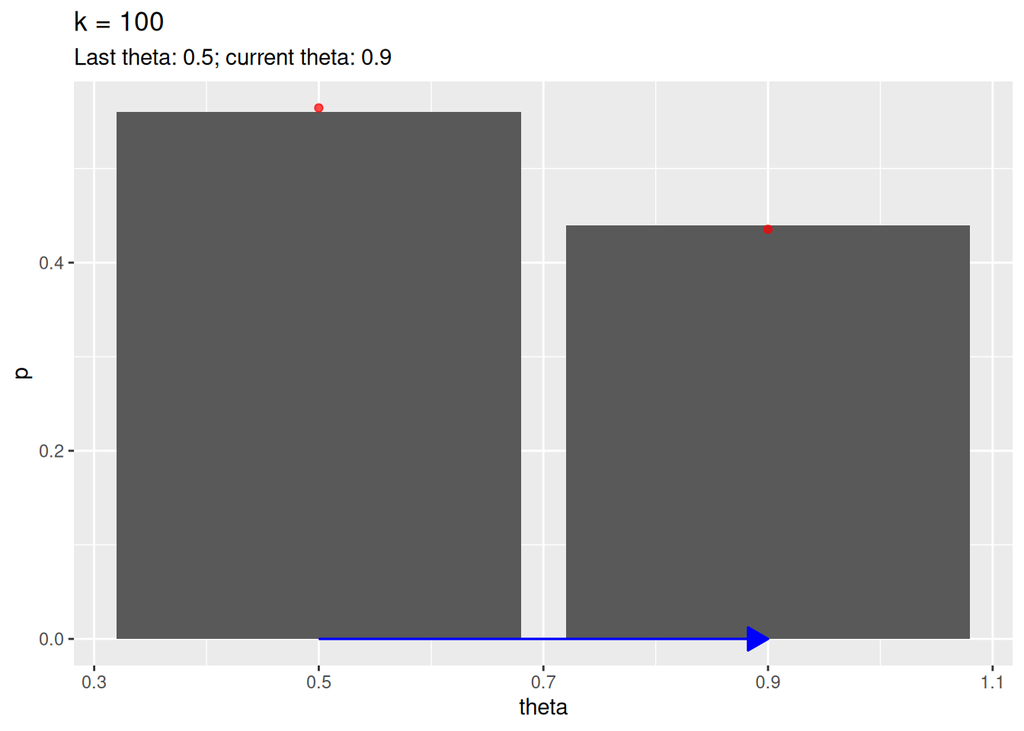

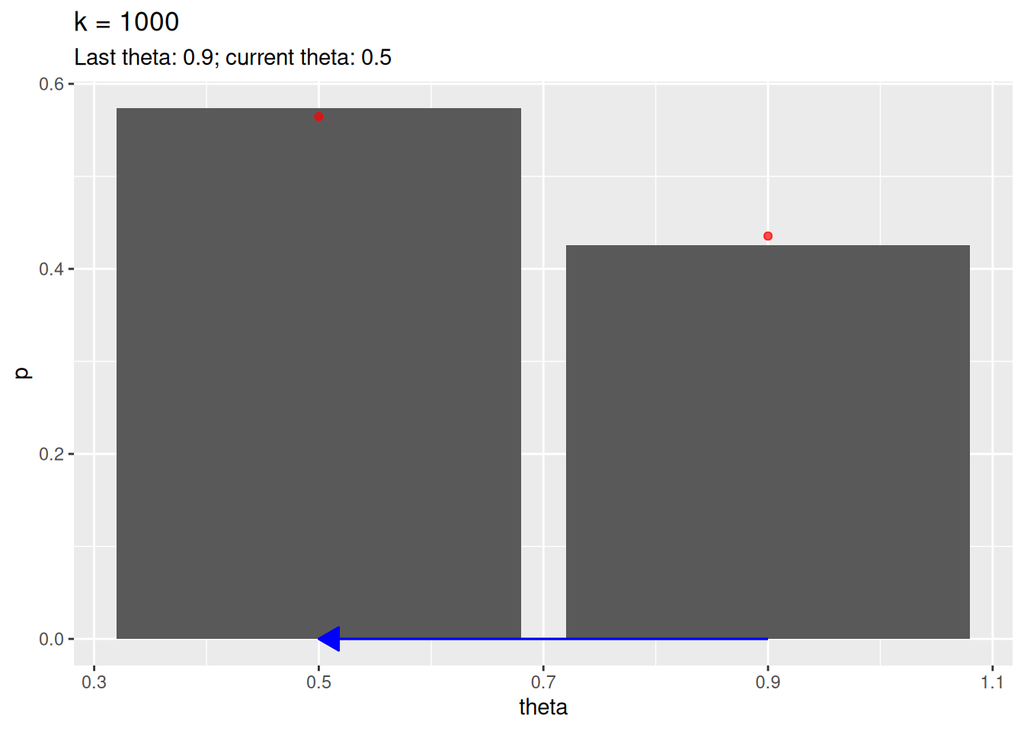

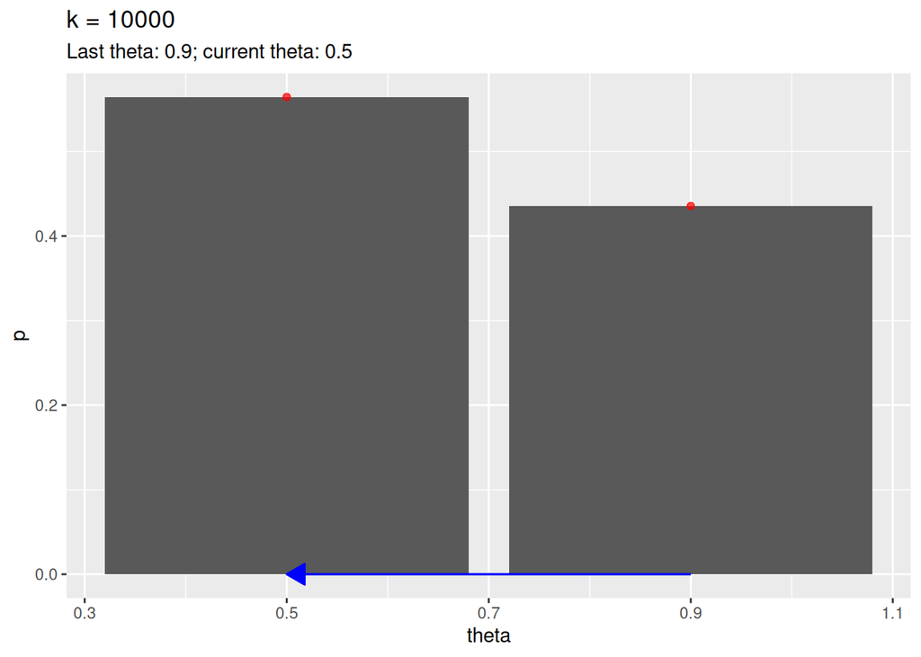

```r
library(tidyverse)
real_posterior <- tibble(theta = c(0.5, 0.9), p = c(0.35 / 0.62, 0.27 / 0.62))

set.seed(12345)

# initialize
current_theta <- 0.5
theta_samples <- c()

K <- 10000
for (k in 1:K) {
  # keep track of last value of theta for plotting later
  last_theta <- current_theta

  # MCMC part ----------
  if (current_theta == 0.9) {
    # always transition to higher probability state
    current_theta <- 0.5
  } else if (current_theta == 0.5) {
    # transition to lower probability state with probability = ratio:
    tr_or_not <- rbinom(1, 1, prob = 0.27 / 0.35)

    if (tr_or_not) {
      # transition success
      current_theta <- 0.9
    } else {
      # do not transition (stay put)
      current_theta <- current_theta
    }
  }

  # collect current theta sample
  theta_samples <- c(theta_samples, current_theta)

  # end of MCMC part------------

  # just plotting
  if (k %in% c(1:6, 100, 1000, 10000)) {
    current_tabulation <- tibble(
      theta = c(0.5, 0.9),
      p = c(
        sum(theta_samples == 0.5) / length(theta_samples),
        sum(theta_samples == 0.9) / length(theta_samples)
      )
    )

    current_plot <- ggplot(current_tabulation, aes(x = theta, y = p)) +
      geom_col() +
      geom_point(data = real_posterior, alpha = 0.7, colour = "red") +
      labs(
        title = str_c("k = ", k),
        subtitle = str_c(
          "Last theta: ",
          last_theta,
          "; current theta: ",
          current_theta
        )
      )

    if (last_theta != current_theta) {
      current_plot <- current_plot +
        geom_segment(
          x = last_theta,
          xend = current_theta,
          y = 0,
          colour = "blue",
          arrow = arrow(length = unit(.4, "cm"), type = "closed")
        )
    }

    print(current_plot)
  }
}
```